# Untitled

Sankarshan Acharya

May 15, 2016

## Loading and preprocessing the data into R

The following step loads the requisite data into R.

```r
monitoring_activity <- read.csv("C:/Users/sanka/Documents/activity.csv")
```

## What is mean total number of steps taken per day?

The following does a graphical analysis on the data and creates a histogram with the mean and the median represented.

```r
activity_array <- array(0, 61)

i = NULL
for(i in 1:61)
{
  a = 288*i - 287
  b = 288*i
  activity_array[i] <- sum(monitoring_activity[a:b, 1])
}

monitoring_activity$Total_Steps <- 0

i = NULL
for(i in 1:17568)
{
  if(i %% 288 != 0)
  {
    a = i %/% 288
    monitoring_activity$Total_Steps[i] <- activity_array[a + 1]
  }

  else
  {
    monitoring_activity$Total_Steps[i] <- activity_array[i/288]
  }
}

c_activity_array = NULL
i = NULL
for(i in 1:length(activity_array))
{
  if(is.na(activity_array[i]))
  {
    c_activity_array = c(c_activity_array, 0)
  }

  else
  {
    c_activity_array = c(c_activity_array, activity_array[i])
  }
}

paste("The mean of the data is", mean(c_activity_array))
```

```
## [1] "The mean of the data is 9354.22950819672"
```

```r
paste("The mean of the data is", median(c_activity_array))
```

[output not shown]

The following is the plot of the histogram with the mean and median displayed:

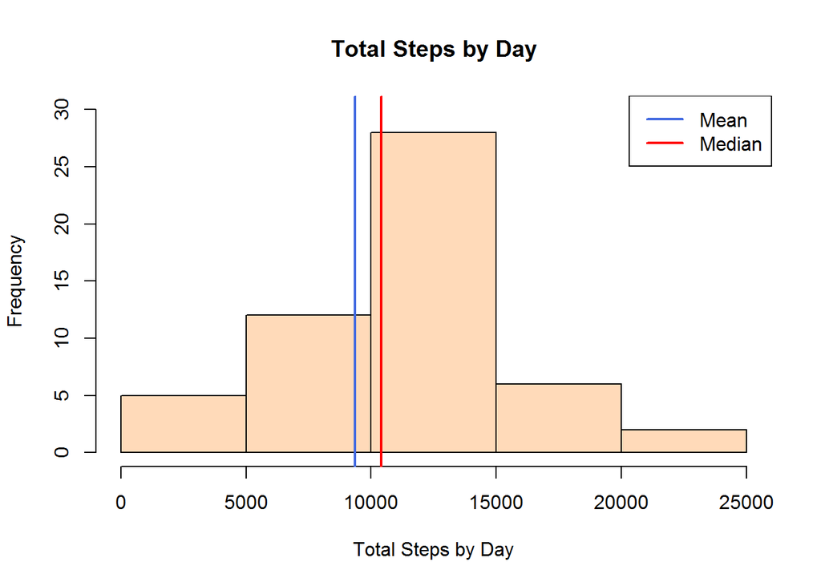

```r
hist(activity_array, col = "peachpuff", xlab = "Total Steps by Day", main = "Total Steps by Day", ylim = c(0, 30))
abline(v = mean(c_activity_array), col = "royalblue", lwd = 2)
abline(v = median(c_activity_array), col = "red", lwd = 2)
legend(x = "topright", c("Mean", "Median"), col = c("royalblue", "red"), lwd = c(2, 2))
```

## What is the average daily activity pattern?

The following code looks at each 5-minute interval data and averages them over every day in the dataset.

```r
activity_array_1 <- array(0, 288)
day_time_count_array <- monitoring_activity$steps

i= NULL
for(i in 1:17568)
{
  a = is.na(day_time_count_array[i])
  if(a)
  {
    day_time_count_array[i] = 0
  }
}

i = NULL
for(i in 1:288)
{
  activity_array_1[i] <- mean(day_time_count_array[seq(i, i + 17280, by = 288)])
}

x <- monitoring_activity[1:288, 3]

a = which.max(activity_array_1)
paste("The interval containing the max interval is", x[a])
```

```
## [1] "The interval containing the max interval is 835"
```

The following is the line plot of the average number of steps (averaged over all the days) given by each 5-minute interval:

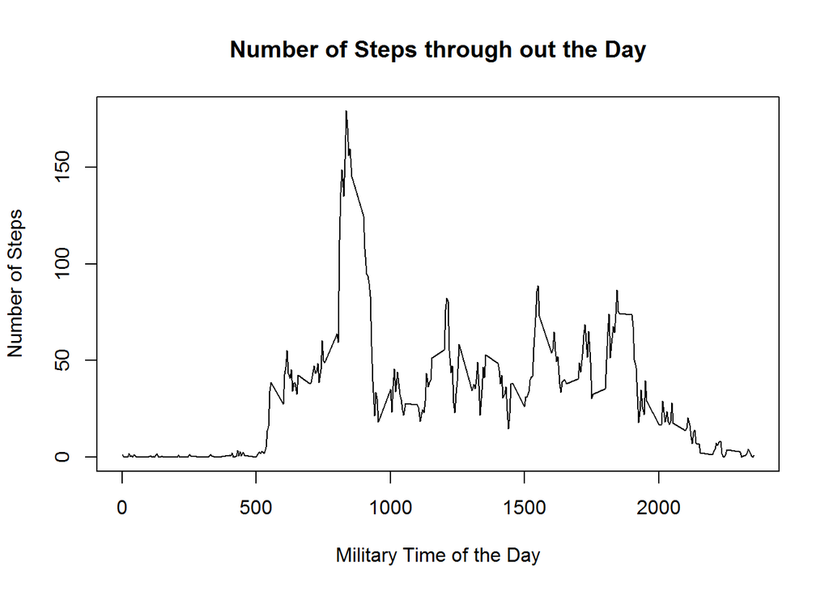

```r
plot(x, activity_array_1, type = "n", xlab = "Military Time of the Day", ylab = "Number of Steps", main = "Number of Steps through out the Day")
lines(x, activity_array_1, type = "l")
```

## Imputing missing values

[output not shown]

[output not shown]

[output not shown]

The following code is used to create the histogram of step numbers given the fact that all the NA spots have been filled:

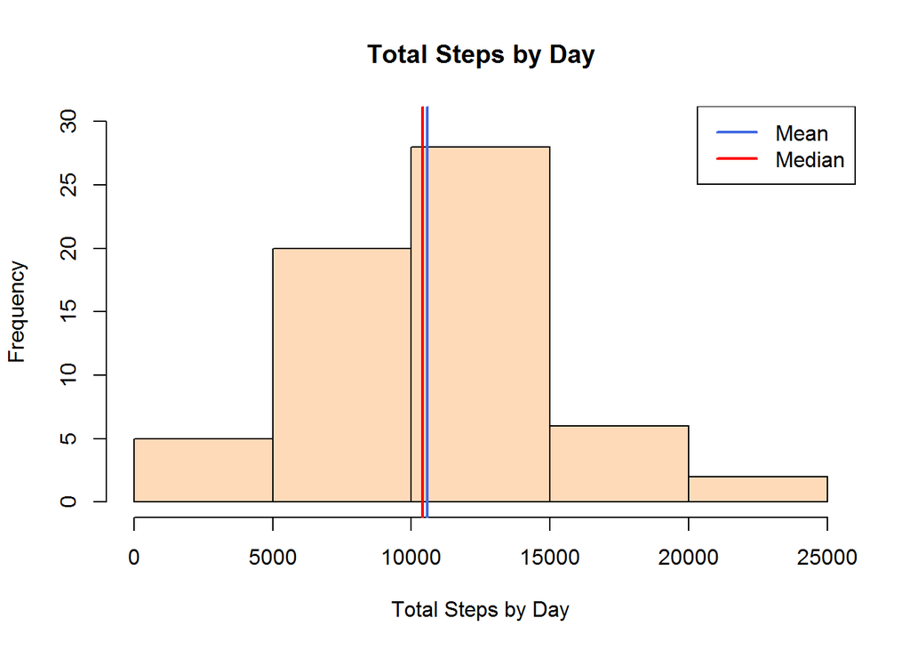

```r
hist(activity_array_NA, col = "peachpuff", xlab = "Total Steps by Day", main = "Total Steps by Day", ylim = c(0, 30))
abline(v = mean(activity_array_NA), col = "royalblue", lwd = 2)
abline(v = median(activity_array_NA), col = "red", lwd = 2)
legend(x = "topright", c("Mean", "Median"), col = c("royalblue", "red"), lwd = c(2, 2))
```

## Are there differences in activity patterns between weekdays and weekends?

The following code graphs the data based on the information given about the averages of the 5-minute intervals in the weekdays and the weekends (days).

```r
monitoring_activity_non_NA$day_type <- 0
i = NULL
for(i in 1:17568)
{
  a <- weekdays(as.Date(monitoring_activity_non_NA$date[i]))

  if(a == "Saturday" || a == "Sunday")
  {
    monitoring_activity_non_NA[i, 5] <- "weekend"
  }

  else
  {
    monitoring_activity_non_NA[i, 5] <- "weekday"
  }
}

monitoring_activity_non_NA_weekday = monitoring_activity_non_NA[monitoring_activity_non_NA$day_type == "weekday", ]
monitoring_activity_non_NA_weekend = monitoring_activity_non_NA[monitoring_activity_non_NA$day_type == "weekend", ]

activity_array_1_NA_weekday <- array(0, 288)
activity_array_1_NA_weekend <- array(0, 288)
day_time_count_array_NA_weekday <- monitoring_activity_non_NA_weekday$steps
day_time_count_array_NA_weekend <- monitoring_activity_non_NA_weekend$steps

i = NULL
for(i in 1:288)
{
  activity_array_1_NA_weekday[i] <- mean(day_time_count_array_NA_weekday[seq(i, i + 12672, by = 288)])
  activity_array_1_NA_weekend[i] <- mean(day_time_count_array_NA_weekend[seq(i, i + 4320, by = 288)])
}

x <- monitoring_activity[1:288, 3]
```

The following code is used to plot the average of the 5-minute intervals over the weekdays first and then to plot the average of the 5-minute intervalse over the weekends:

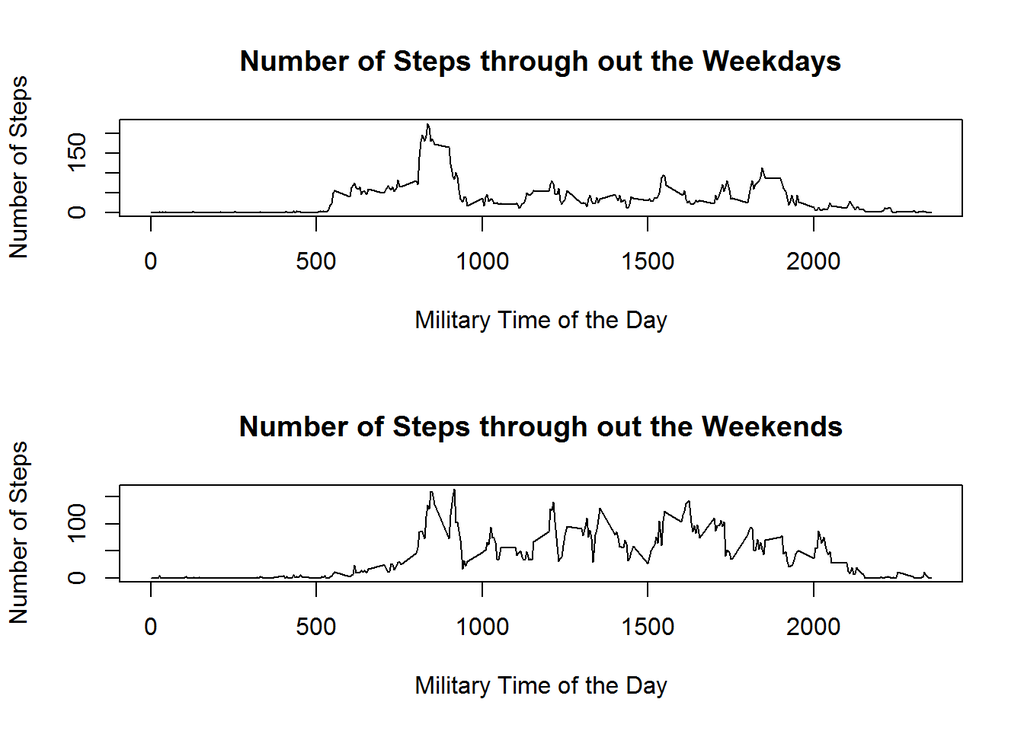

```r
par(mfrow=c(2,1))

plot(x, activity_array_1_NA_weekday, type = "n", xlab = "Military Time of the Day", ylab = "Number of Steps", main = "Number of Steps through out the Weekdays")
lines(x, activity_array_1_NA_weekday, type = "l")

plot(x, activity_array_1_NA_weekend, type = "n", xlab = "Military Time of the Day", ylab = "Number of Steps", main = "Number of Steps through out the Weekends")
lines(x, activity_array_1_NA_weekend, type = "l")
```